# Loan Status Prediction of Bank Clients

Sean Cooke R00181896

6th December 2018

## Summary

Detailed model building was carried out based on ABC Bank’s loan clients with the main goal of improving decision making when classifying the credit standing of future customers. The bank’s current customer data was used to train various models in R Studio, with the pruned decision tree model being the most accurate at predicting whether a client’s credit standing was Good or Bad. This model was then deployed and used on a selection of new loan clients in order to classify their potential creditworthiness.

## Introduction

ABC Bank has a loan portfolio consisting of 780 customers and various details are known about each client, such as employment status, housing type, martial status and age amongts others. The bank uses a mixture of their own in-house grading system and human input to grade each customer’s credit standing as either “Good” or “Bad”. The customer rating currently sits at 60% “Good”. However, mistakes are sometimes made, so the bank would like to increase the accuracy of their decision making process due to the cost of misclassiying a Bad loan as Good, which can be quite high.

The project we will go through the stages of a methodology known as “CRISP-DM” [r1] which stands for “cross-industry process for data mining”. CRISP-DM has the following six stages:

## Loading Packages

The first step is to load the required packages into R Studio . **Note:** If the reader wishes to run the code supplied with this report, you must place the accompanying csv files in your working directory, and the directory in the read_csv function below must be changed to your working directory. The following packages must also be installed:

```r
 # install.packages("readr")
 # install.packages("aCRM")
 # install.packages("DataExplorer")
 # install.packages("ggplot2")
 # install.packages("caTools")
 # install.packages("caret")
 # install.packages("rms")
 # install.packages("plottr")
 # install.packages("PerformanceAnalytics")
 # install.packages("dplyr")
 # install.packages("tree")
 # install.packages("randomForest")
 # install.packages("pROC")
 # install.packages("ROCR")
 # install.packages("gbm")
 # install.packages("DT")
# install.packages("gbm")
```

```r
library(DT)
library(gbm)
library(ROCR)
library(pROC)
library(dplyr)
library(PerformanceAnalytics)
# library(DataExplorer)
library(readr) # for reading csv
library(aCRM) # for impute missings
library(ggplot2)
library(caTools) # for sample.split
library(caret)
# library(rms)
library(tree)
library(randomForest)
```

## Exploratory Data Analysis

The dataset was first opened in Microsoft Excel for some light editing before more techical work began. The spaces were removed from column names, as were unweidly characters such as parentheses . Column names were simplified and one minus number was found in the “Residence Time in Cureent District” column. This negative number was replaced with the median residence time.

For further cleaning, the dataset was imported into Rstudio. Names of the columns were changed to lower case. There were some, but not many, missing values in the dataset, so the function imputeMissings() was called using the aCRM package[2], which uses the mode of the variable to fill in the missing values. In the case of numeric variables, the median is used. The structure is then checked to ensure all the variables are encoded correctly - factor or numeric. Finally the ID column was removed as this serves no value in predicting credit standing.

```r
Testing <- read.csv("D:/Semester 1/DSA/Credit Project/attempt 2/For Submission/Testing.csv")

names(Testing) <- tolower(names(Testing))
dim(Testing)
# describe(Testing)
Testing <- imputeMissings(Testing)
str(Testing)
Testing$id <- NULL
```

```
##  [1] "checkingacct"   "credithistory"  "loanreason"     "savingsacct"
##  [5] "employment"     "personalstatus" "housing"        "jobtype"
##  [9] "foreign"        "monthsopened"   "residencetime"  "age"
## [13] "creditstanding"
```

```
##   checkingacct   credithistory           loanreason   savingsacct
##  High   : 45   All Paid :138   Car New        :191   High   : 29
##  Low    :201   Bank Paid: 63   Small Appliance:186   Low    :500
##  No Acct:271   Critical : 92   Furniture      :160   MedHigh: 49
##  Zero   :263   Current  :423   Business       : 82   MedLow : 80
##                Delay    : 64   Car Used       : 75   No Acct:122
##                                Education      : 45
##                                (Other)        : 41
##       employment   personalstatus  housing          jobtype    foreign
##            : 33           :  6         :  5   Management:101   No :253
##  Long      :186   Divorced:273    Other: 94   Skilled   :498   Yes:527
##  Medium    :140   Married : 70    Own  :524   Unemployed: 19
##  Retired   :  2   Single  :431    Rent :157   Unskilled :162
##  Short     :242
##  Unemployed: 43
##  Very Short:134
##   monthsopened   residencetime         age        creditstanding
##  Min.   :  5.0   Min.   : 1.000   Min.   :18.00   Bad :319
##  1st Qu.: 13.0   1st Qu.: 2.000   1st Qu.:26.00   Good:461
##  Median : 19.0   Median : 3.000   Median :32.00
##  Mean   : 23.2   Mean   : 2.874   Mean   :34.75
##  3rd Qu.: 29.5   3rd Qu.: 4.000   3rd Qu.:41.00
##  Max.   :120.0   Max.   :10.000   Max.   :99.00
##
```

|  | checkingacct | credithistory | loanreason | savingsacct | employment | personalstatus | housing | jobtype | foreign | monthsopened | residencetime | age | creditstanding |
| --- | --- | --- | --- | --- | --- | --- | --- | --- | --- | --- | --- | --- | --- |
| 1 | Zero | Current | Furniture | Low | Long | Single | Other | Management | Yes | 13 | 3 | 52 | Good |
| 2 | No Acct | All Paid | Small Appliance | Low | Medium | Single | Own | Unskilled | Yes | 5 | 1 | 41 | Good |
| 3 | No Acct | All Paid | Small Appliance | Low | Medium | Single | Own | Unskilled | No | 5 | 1 | 41 | Good |
| 4 | No Acct | All Paid | Small Appliance | Low | Medium | Single | Own | Unskilled | Yes | 5 | 1 | 41 | Good |
| 5 | No Acct | All Paid | Small Appliance | Low | Medium | Single | Own | Unskilled | Yes | 5 | 1 | 41 | Good |
| 6 | Zero | Current | Furniture | Low | Long | Divorced | Own | Skilled | Yes | 7 | 1 | 48 | Good |

The below proportions of Bad to Good loans gives the baseline rate, which in this case is 59%. If the bank simply categorizes all loans as “Good”, they would be correct 59% of the time. This will also be used as a benchmark when evaluating the performance of prediction models.

```
##
##  Bad Good
## 0.41 0.59
```

## Visualising the Customer Data

The majority of customers are short term employed, which is slightly surprising as approximately 60% of the banks loans are classified as “Good”. One would think short term employed customers would be a riskier group to lend to. Perhaps they make up the a sizeable proportion of the 40% Bad loans.

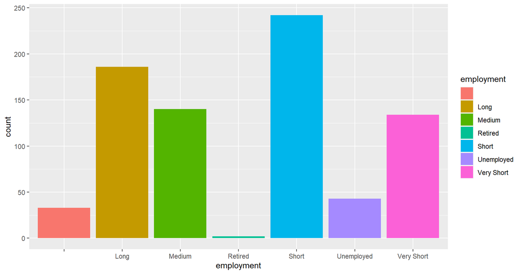

The dataset is slightly imbalanced with more Good loans than Bad.

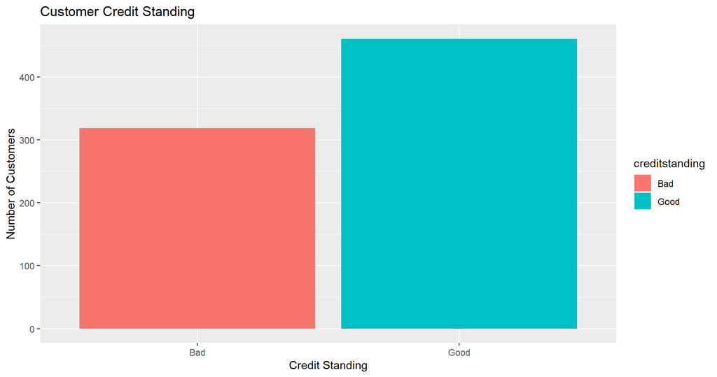

The majority of loan recipients are under 50 years of age, and it seems like the 18 to 30 age bracket have the highest number of loans.

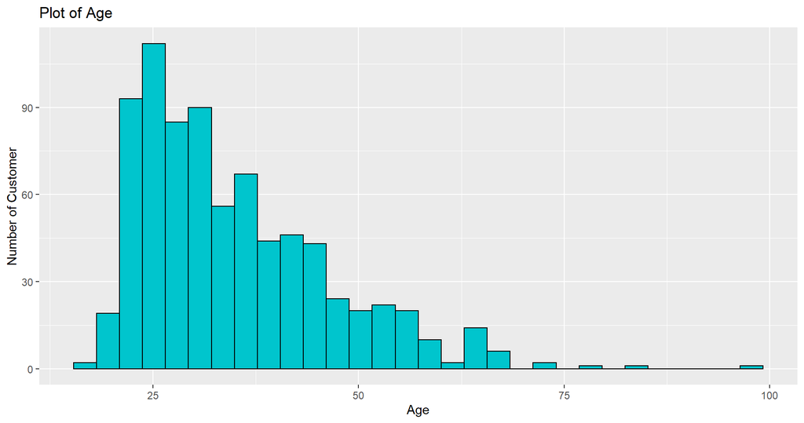

In the below diagram the relationship between employment type and credit history can be seen in terms of credit standing. Along the top are the labels for each type of employment. Down the right hand side are the different levels of credit history, and at each intersection we have the number of good versus bad loans. It is obvious to see that customers in short term unemployment with either critical or current credit history have a higher proportion of bad loans compared to the rest of the customers. During model building it will become evident if these two variables are important in determining the status of a loan.

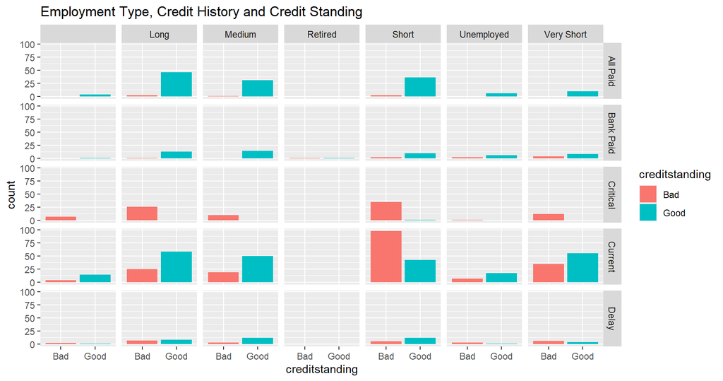

Since credit history seemed to play a strong role in the above diagram, it was isolated for the blow plot against credit standing to get the proportions for each credit history type. Critical has the highest proportion of bad loans.

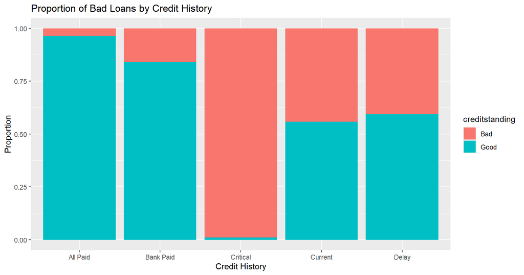

And finally a look at the distribution of age and credit standing. It is quite an equal distribution and it seems like age may not play a very strong role in determining if a loan should be categorized as good or bad.

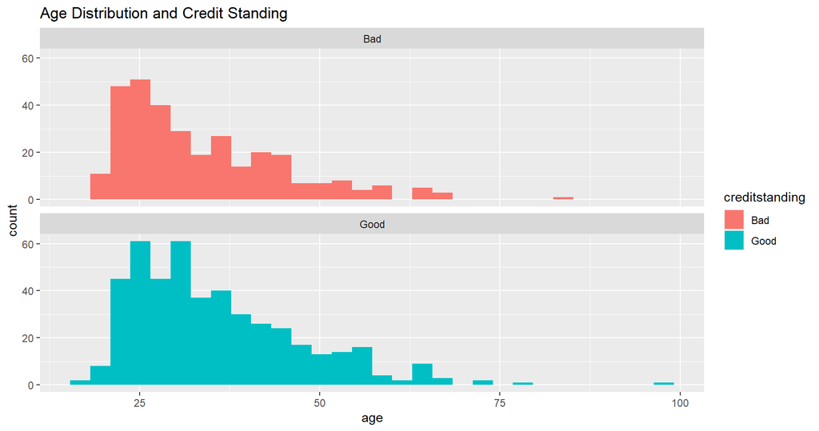

## Model Building

#### Creating a Decision Tree

A decision tree model will be developed in order to categorize loans as good or bad. In the below code an 80/20 split is made on the original data, creating a training set (80%) and testing set (20%). The tree will learn using the training data while final prediction accuracy will be evaluated using the 20% test set.

```r
set.seed(896)
sample <- sample.split(Testing$creditstanding, 0.8)
train.data <- subset(Testing, sample==TRUE)
test.data <- subset(Testing, sample==FALSE)
set.seed(896)
mytree=tree(creditstanding~.,data=train.data)
```

```
##
## Classification tree:
## tree(formula = creditstanding ~ ., data = train.data)
## Variables actually used in tree construction:
## [1] "credithistory" "employment"    "residencetime" "age"
## [5] "checkingacct"  "savingsacct"
## Number of terminal nodes:  13
## Residual mean deviance:  0.8001 = 488.9 / 611
## Misclassification error rate: 0.1971 = 123 / 624
```

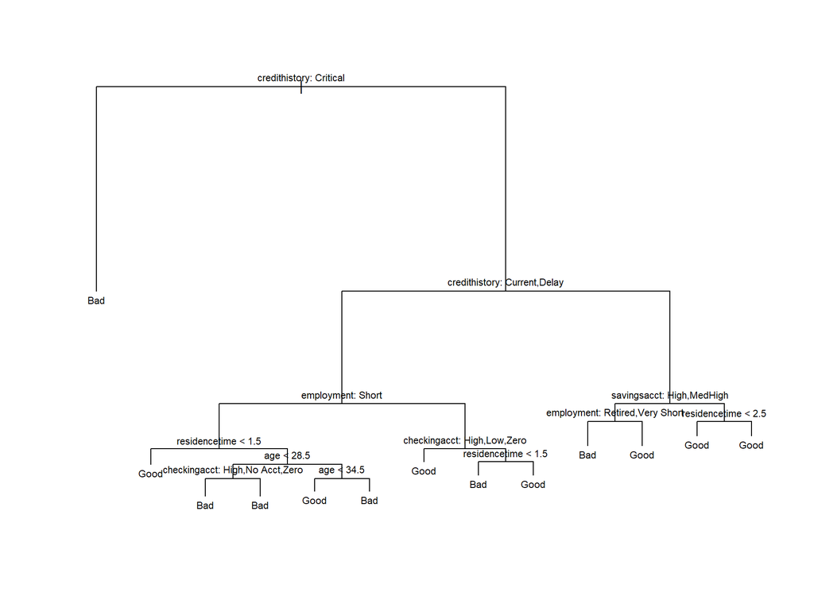

The decision tree is then applied to the 20% testing data and used to predict the credit standing for each customer in that dataset. Performance can be analysed using a confusion matrix which shows when the model misclassified good as bad and vice versa, and correctly classiffied good and bad. Simple calculations can also be carried out using this confusion matrix, such as Accuracy, False Positive Rate, and Misclassification Error.

```
##           actual
## Prediciton Bad Good
##       Bad   34    9
##       Good  30   83
```

```
## Missclassification error: 0.25
```

#### Fine tuning the Decision Tree

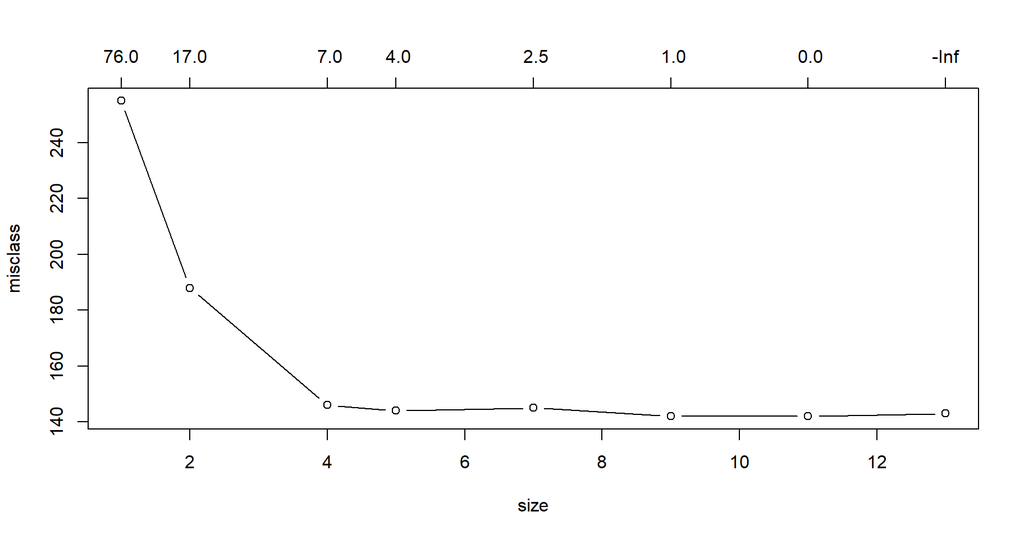

```r
set.seed(896)
mytree.cv=cv.tree(mytree,FUN = prune.misclass)
plot(mytree.cv,type="b")
```

The tree is pruned to four nodes with the following code below. The diagram of this new tree shows a clearly simplified structure compared to the unpruned tree earlier. It does however have a higher misclassification error, but it is yet to be tested on the test dataset.

```r
set.seed(896)
mytree.prune=prune.tree(mytree,best=4)
summary(mytree.prune)
```

```
##
## Classification tree:
## snip.tree(tree = mytree, nodes = c(13L, 12L, 7L))
## Variables actually used in tree construction:
## [1] "credithistory" "employment"
## Number of terminal nodes:  4
## Residual mean deviance:  0.9503 = 589.2 / 620
## Misclassification error rate: 0.2324 = 145 / 624
```

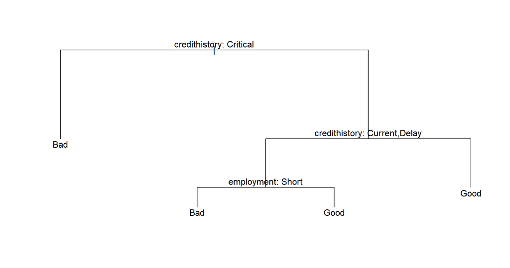

```r
plot(mytree.prune);text(mytree.prune,pretty=0)
```

```r
summary(mytree)
```

```
##
## Classification tree:
## tree(formula = creditstanding ~ ., data = train.data)
## Variables actually used in tree construction:
## [1] "credithistory" "employment"    "residencetime" "age"
## [5] "checkingacct"  "savingsacct"
## Number of terminal nodes:  13
## Residual mean deviance:  0.8001 = 488.9 / 611
## Misclassification error rate: 0.1971 = 123 / 624
```

The newly pruned tree will now be used to predict the test data credit standing. As seen below, the pruned tree has virtually the same misclassification error as the unpruned tree when used on the test data. It is generally better to go with a less complex model if measures of accuracy are virutally identical (occam’s razor) so in this case the pruned tree should be selected.

```r
mytreepred=predict(mytree.prune,test.data,type = "class")
table(mytreepred,test.data$creditstanding)
```

```
##
## mytreepred Bad Good
##       Bad   39   11
##       Good  25   81
```

```r
cat("Missclassification error:",mean(mytreepred != test.data$creditstanding))
```

```
## Missclassification error: 0.2307692
```

## Using the Model on our Scoring Data

#### Predicting new customer loans as Good or Bad.

```r
scoring <- read.csv("C:/Allegiant/My_CIT_R_Stuff/Scoring.csv")
scoring$id <- NULL
names(scoring) <- tolower(names(scoring))
set.seed(896)
Three_Clients <- scoring[sample(nrow(scoring), 3), ]
Three_Clients$creditstanding<-predict(mytree.prune,Three_Clients, type="class")
datatable(Three_Clients, extensions = 'FixedColumns',options = list(dom = 't',scrollX = T,fixedColumns = T))
```

[output not shown]

## Random Forests and GBM Boosting

Two extra models will be developed to determine if accuracy rates can be improved - Random Forests and Gradient Boosting.

#### Random Forests

The first step in the random forests model development is to get the optimum “mrtry” number for a random forest model. Mtry is the number variables randomly sampled and used for decision making at each node in the model. Tpyically the square root of the numbr of predictors is the recommended mtry,[4] but in this instance the tuneRF function will be used to identify this number.

```r
set.seed(896)
bestmtry <- tuneRF(train.data[-13],train.data$creditstanding,improve = .01,trace = T,doBest = FALSE)
```

```
## mtry = 3  OOB error = 25%
## Searching left ...
## mtry = 2     OOB error = 23.4%
## 0.06410256 0.01
## mtry = 1     OOB error = 27.56%
## -0.1780822 0.01
## Searching right ...
## mtry = 6     OOB error = 23.72%
## -0.01369863 0.01
```

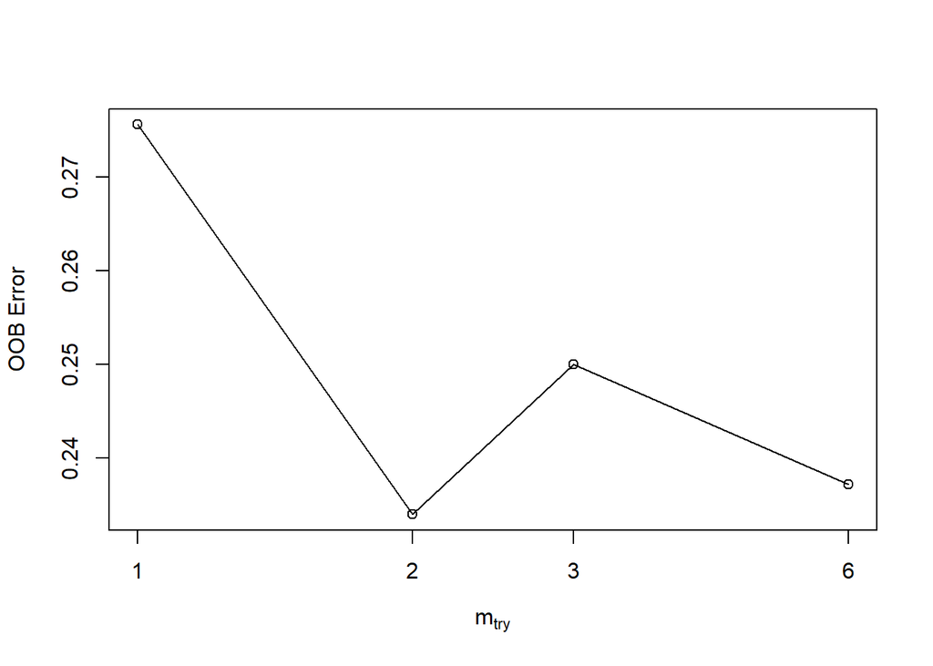

```r
datatable(bestmtry)
```

|  | mtry | OOBError |
| --- | --- | --- |
| 1.OOB | 1 | 0.275641025641026 |
| 2.OOB | 2 | 0.233974358974359 |
| 3.OOB | 3 | 0.25 |
| 6.OOB | 6 | 0.237179487179487 |

```r
set.seed(896)
Tree.rf <- randomForest(creditstanding~.,data = train.data, mtry=6, importance=TRUE,ntree=1000)
Tree.rf$confusion
```

```
##      Bad Good class.error
## Bad  178   77   0.3019608
## Good  69  300   0.1869919
```

The influence of each of the variables on the response variable can be seen in this plot. Credit history seems to have a strong influence, followed by employment then age.

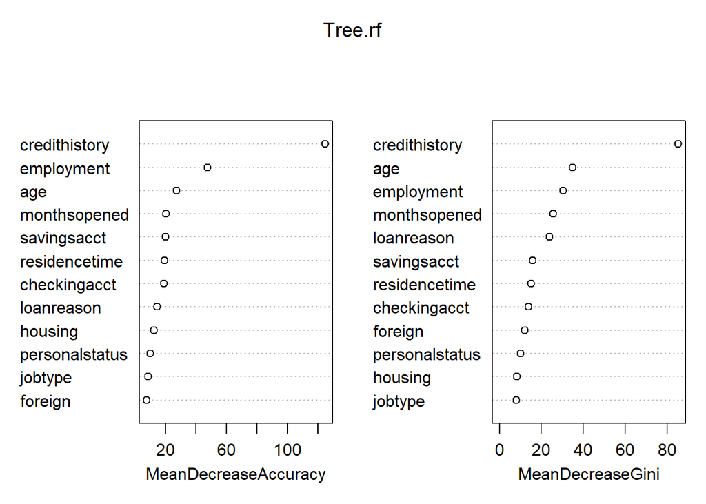

```r
varImpPlot(Tree.rf)
```

The random forest model is then used to predict the test data response variable. A misclassification score of .28 means that this model is performing worse than our basic decision tree, which had a misclassification error of .23. The next model to try is the Gradient Boosting method.

```r
RFpred <- predict(Tree.rf,test.data,type="class")
table(RFpred,test.data$creditstanding)
```

```
##
## RFpred Bad Good
##   Bad   39   19
##   Good  25   73
```

```r
print(mean(RFpred != test.data$creditstanding))
```

```
## [1] 0.2820513
```

#### Boosting with GBM

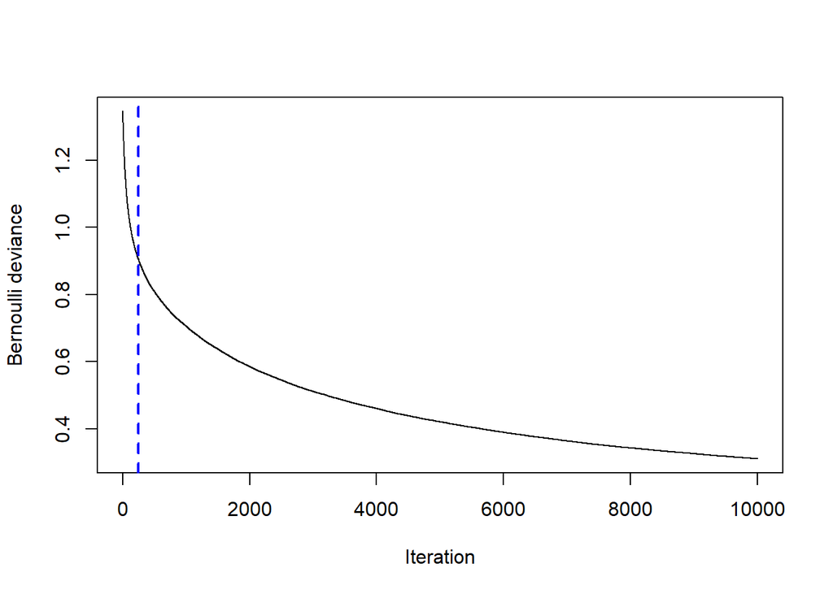

```r
train.data$creditstanding <- ifelse(train.data$creditstanding == "Bad", 0, 1)
test.data$creditstanding <- ifelse(test.data$creditstanding == "Bad", 0, 1)
set.seed(896)
boost.data=gbm(creditstanding~.,data=train.data,distribution="bernoulli",n.trees=10000, interaction.depth=3,shrinkage = .01)
ntree_opt_oob <- gbm.perf(plot.it = T,boost.data, method = "OOB")
```

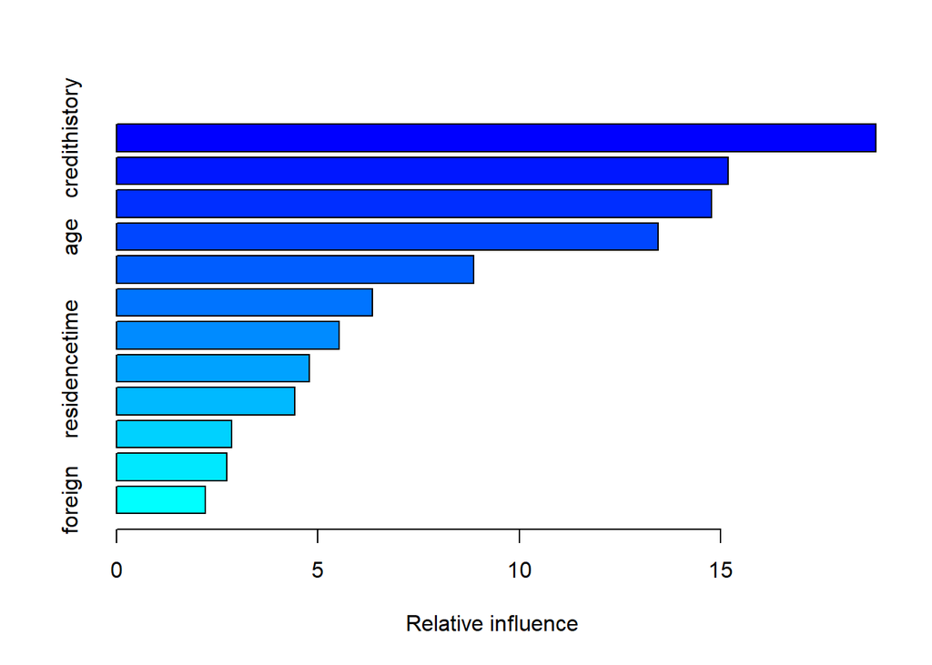

```
##                           var   rel.inf
## credithistory   credithistory 18.844550
## employment         employment 15.185534
## loanreason         loanreason 14.775356
## age                       age 13.442926
## monthsopened     monthsopened  8.873481
## savingsacct       savingsacct  6.348480
## checkingacct     checkingacct  5.526857
## residencetime   residencetime  4.779284
## personalstatus personalstatus  4.420365
## housing               housing  2.861464
## jobtype               jobtype  2.738211
## foreign               foreign  2.203492
```

```r
summary(boost.data)
```

```r
Myboost=predict(boost.data,test.data,n.trees=10000,type ="response")
MyboostROC <- Myboost
train.data$creditstanding <- as.factor(ifelse(train.data$creditstanding == 0, "Bad", "Good"))
test.data$creditstanding <- as.factor(ifelse(test.data$creditstanding == 0, "Bad", "Good"))
Myboost <- as.factor(ifelse(Myboost>0.5,"Good","Bad"))
table(Myboost,test.data$creditstanding)
```

```
##
## Myboost Bad Good
##    Bad   39   17
##    Good  25   75
```

```r
print(mean(Myboost != test.data$creditstanding))
```

```
## [1] 0.2692308
```

#### Which model to choose?

A review of the different misclassification errors of the models developed:

Pruned Deciusion Tree: 23%

Random Forests: 28%

It is clear that the original decision trees are the best models, specifically the pruned decision tree. Pruning reduced complexity without sacrificing accuracy, and is also easier to visualise and explain.

## Cost of Misclassification

One noticeable feature of the results was that there was actually a high number of instances where bad was classified as good, which is perhaps due to the dataset’s slight imbalance towards good loans. Training a model on an imbalanced dataset can sway it towards classifying the majority class more often than not due to the learning process focusing on accuracy without taking the proportion of classes into account.[5] Therefore models were slightly biased and were more likely to classify a loan as good rather than bad

The bank has stated that the cost of misclassifying a bad loan as good can be five times as costly as misclassfying a good loan as bad. To rectify this, the best model can be re-trained to give more accurate results. For this, downsampling will be used.

The original dataset will be downsampled so both Good and Bad observations have a 50/50 split. New training and test sets will be created and the best model, currently either the pruned decision tree or original tree, will be retrained with this data. The regular decision tree will be used without the extra step of pruning for simplicity as they both have virtually the same performance.

```r
set.seed(896)
Testing2 <- downSample(yname = "creditstanding",Testing[-13], Testing$creditstanding)
nrow(Testing2[Testing2$creditstanding=="Good",])/nrow(Testing2)
```

```
## [1] 0.5
```

```r
set.seed(896)
sample <- sample.split(Testing2$creditstanding, 0.8)
train.data2 <- subset(Testing2, sample==TRUE)
test.data2 <- subset(Testing2, sample==FALSE)
```

```r
set.seed(896)
mytree=tree(creditstanding~.,data=train.data2)
set.seed(896)
mytreepred=predict(mytree,test.data,type = "class")
table(mytreepred,test.data$creditstanding)
```

```
##
## mytreepred Bad Good
##       Bad   46   23
##       Good  18   69
```

Further testing could be done to increase accuracy or balance out the confusion matrix, such as reclassifying Good and Bad as 1 and 0, and creating logistic regression models which output probabilities rather than classification models, and adjusting the threshold of where exactly a result is graded as Good or Bad. For example, does a probability of 0.5 mean the loan is Good? What about 0.6 or 0.4? Finding the best threshold can be done with the help of a ROC curve which is discussed in question (b) at the end of the report. Further model building and tuning may need to be carried out if the bank is not satisfied with the re-trained model.

#### Consecutive numbers?

In order to find a suspicious grading pattern in the banks dataset, I used the pruned decision tree to predict the results on the original unpslit data - no test or training. I thought there may be a suspicious pattern when comparing actual results and predicted results in Excel but nothing jumped out at me.

I then filtered the data in excel manually according to the classification criteria of the decision tree for each “Bad” result ie. Delay in Credit History + Loan Reason: Furniture etc. however no consecutive or suspicious pattern was found.

#### ROC Curve

An ROC Curve is a plot of the true positive rate ( TPR: how often a model correctly predicts a positive eg. yes, good or 1) against the false positive rate of the same model (FPR: how often the model incorrectly predicts a positive when it is actually a negative). The ROC curve can show how well a model distinguishes between these two classifiers and can also be used to tell what the optimum threshold is for converting probabilities to a classification.[6] For example, a model may generally classify a response as “Yes” for probabilities of 0.5 and above and “No” for those below. Tuning this threshold up or down may result in more satisfactory prediction rates. The curve contains all TPR and FPR for every possible threshold which ranges from 0 to 1, and the higher the curve is (or the greater the area under the curve is), the better the model is at predicting classes.

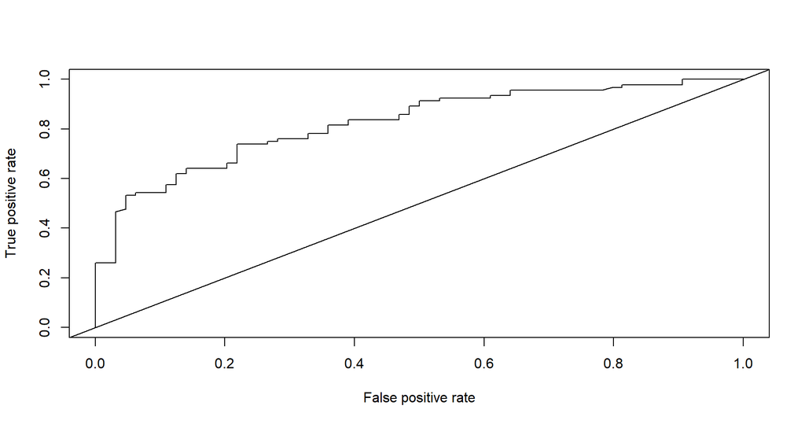

#### References

[1] https://www.sv-europe.com/crisp-dm-methodology/

[2] https://www.rdocumentation.org/packages/aCRM/versions/0.1.1

[3] James, G. (2013) *An Introduction to Statistical Learning* Chapter 8 pages 303-307.

[4] James, G. (2013) *An Introduction to Statistical Learning* Chapter 8 page 320

[5] https://www.svds.com/learning-imbalanced-classes/

[6] https://www.youtube.com/watch?v=ypO1DPEKYFo

[7] James, G. (2013) *An Introduction to Statistical Learning* Chapter 4 pages 147-148